# Exploring Data Frames

At this point, you’ve seen it all: in the last lesson, we toured all the basic data types in R. Everything you do will be a manipulation of those types. Now we need to look at *data structures* - that is, a more complex structure which R builds out of the basic data types.

But most of the time, the star of the show is the data frame - which is quite similar to an Microsoft Excel sheet. It is type automatically used when an external data set is imported into R. In this lesson, we will learn a few more things about working with data frames.

But, first we need to learn how to load data. One of R’s most powerful features is its ability to deal with tabular data - such as you may already have in a spreadsheet or a CSV file.

The `read.table()` function is used for reading in tabular data stored in a text file where the columns of data are separated by punctuation characters such as CSV files (csv = comma-separated values). Tabs and commas are the most common punctuation characters used to separate or delimit data points in csv files. For convenience R provides 2 other versions of `read.table()`. These are: `read.csv()` for files where the data are separated with commas and `read.delim()` for files where the data are separated with tabs. Of these three functions, `read.csv()` is the most commonly used.

Okay, let’s read some data in! First,we load a data set of pig growth under different feeds.

```r
pig_feed <- read.csv("data/pig_feed_trial.csv")
```

Looking at the environment tab, we can see there are 50 rows of 5 variables. By clicking on the small arrow next to the object name, more information about the variables can be seen.

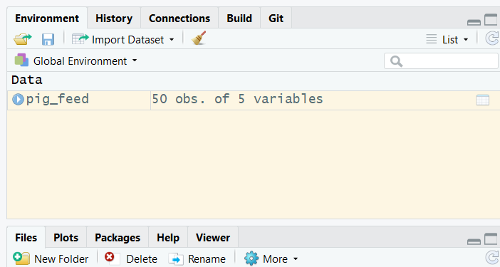

Let’s examine the data manually by clicking on the object name in the “Environment” pane. The data can be sorted by individual columns. Data frames are collections of vectors - that is each column is a single data type.

At this stage, it’s important to ask ourselves if the structure R is reporting matches our intuition or expectations; do the basic data types reported for each column make sense? If not, we need to sort any problems out now before they turn into bad surprises down the road, using what we’ve learned about how R interprets data, and the importance of *strict consistency* in how we record our data.

We can begin exploring columns in our data set by pulling out columns by specifying them using the `$` operator:

```r
weight <- pig_feed$weight2
weight
```

```
##  [1] 195 177 180 200 197 170 150 180 192 184 194 204 200 201 195 187 191
## [18] 200 208 218 203 190 221 173 185 225 190 201 174 180 226 230 218 235
## [35] 197 210 217 205 200 191 242 225 205 228 196 196 230 170 216 175
```

> **Tip**: you an also use `[[` to extract *a single column* from a data frame:

> ```
> pig_feed[["weight2"]]
> ```

Compute some summary statistics on that:

```r
mean(weight)
```

```
## [1] 199.54
```

```r
median(weight)
```

```
## [1] 198.5
```

```r
min(weight); max(weight)
```

```
## [1] 150
```

```
## [1] 242
```

```r
# range(weight) obains both the min and max
var(weight)
```

```
## [1] 380.2943
```

```r
sd(weight)
```

```
## [1] 19.50114
```

```r
summary(weight)
```

```
##    Min. 1st Qu.  Median    Mean 3rd Qu.    Max.
##   150.0   187.8   198.5   199.5   214.5   242.0
```

Or run`summary()`on the entire data frame and use `head()`to view the top 6 rows.

```r
head(pig_feed)
```

```
##   treatment rep weight1 feed weight2
## 1        T1  R1      30  674     195
## 2        T1  R2      21  628     177
## 3        T1  R3      21  661     180
## 4        T1  R4      33  694     200
## 5        T1  R5      27  713     197
## 6        T1  R6      24  585     170
```

```r
summary(pig_feed)
```

```
##  treatment      rep        weight1        feed          weight2
##  T1:10     R1     : 5   Min.   :20   Min.   :575.0   Min.   :150.0
##  T2:10     R10    : 5   1st Qu.:26   1st Qu.:633.2   1st Qu.:187.8
##  T3:10     R2     : 5   Median :30   Median :667.0   Median :198.5
##  T4:10     R3     : 5   Mean   :30   Mean   :676.4   Mean   :199.5
##  T5:10     R4     : 5   3rd Qu.:34   3rd Qu.:715.2   3rd Qu.:214.5
##            R5     : 5   Max.   :41   Max.   :831.0   Max.   :242.0
##            (Other):20
```

Let’s see what is going on in those factors with the function `levels()`;

```r
levels(pig_feed$treatment)
```

```
## [1] "T1" "T2" "T3" "T4" "T5"
```

```r
levels(pig_feed$rep)
```

```
##  [1] "R1"  "R10" "R2"  "R3"  "R4"  "R5"  "R6"  "R7"  "R8"  "R9"
```

```r
table(pig_feed$rep) # to see counts for each level
```

```
##
##  R1 R10  R2  R3  R4  R5  R6  R7  R8  R9
##   5   5   5   5   5   5   5   5   5   5
```

> **Tip**: When working with a character variables, the function `levels()` will return nothing. Use `unique()` to find the unique levels.

Data frames do have a length, but it more clearly described by `ncol()`, `nrow()`, or `dim()`. It also has `rownames()`and `colnames` attributes.

```r
ncol(pig_feed)
```

```
## [1] 5
```

```r
nrow(pig_feed)
```

```
## [1] 50
```

```r
dim(pig_feed)
```

```
## [1] 50  5
```

```r
colnames(pig_feed)
```

```
## [1] "treatment" "rep"       "weight1"   "feed"      "weight2"
```

If you don’t specify the row names during import, then the `read.csv()` function will create an index of integers from 1 to the end of the data frame for row numbers.

The column and row names are vectors. As such, they can be indexed to access a particular item. To rename a column, index it. Since “weight1” is probably the initial weight of each pig, let’s rename it.

```r
colnames(pig_feed)[3] <- "init_wt"
```